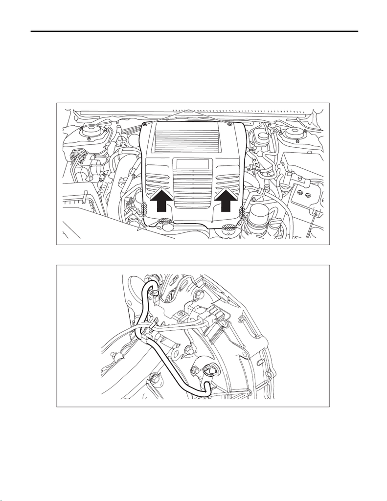

6MT(TY75)-48

Air Breather Hose

MANUAL TRANSMISSION AND DIFFERENTIAL

8. Air Breather Hose

A: REMOVAL

1) Disconnect the ground cable from battery. <Ref. to NT-5, BATTERY, NOTE, Note.>

2) Remove the collector cover.

(1) Remove the clips (A).

(2) Hold the shaded area (B) by hand and carefully pull the RH side (C) upward.

(3) Hold the shaded area (D) by hand and carefully pull the LH side (E) upward.

3) Remove the intercooler. <Ref. to IN(w/o STI)-38, REMOVAL, Intercooler.>

4) Remove the air breather hose.

EX-03204

(A)

(B)

(C)

(E)

(D)

MT-02985

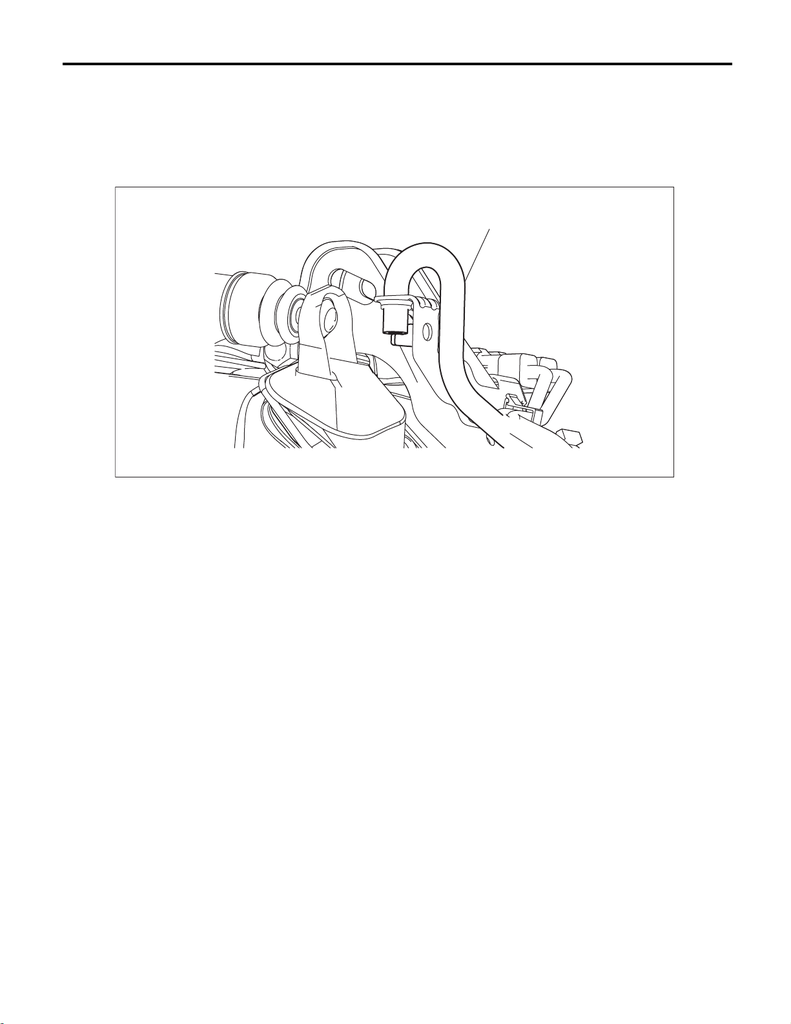

6MT(TY75)-49

Air Breather Hose

MANUAL TRANSMISSION AND DIFFERENTIAL

B: INSTALLATION

Install in the reverse order of removal.

NOTE:

• When installing the air breather hose, pay attention to the positions of the two markings on the hose and

make sure the markings come to the same position as when removed.

• Securely insert the air breather hose until the hose end contacts the catch of the pitching stopper bracket.

C: INSPECTION

Check the hose for peeling, crack or clogging.

(A) Air breather hose (B) Catch

MT-02986

(A)

(B)